# GIS final exam - City of Charlotte Safe Streets for All

Chung-En Tsern

15:10:00, 13 December, 2024

# Originality declaration

I, [**Chung-En Tsern**], confirm that the work presented in this assessment is my own. Where information has been derived from other sources, I confirm that this has been indicated in the work. I used ChatGPT to fix my grammar mistakes and improve the cohesion of the text and solove some coding problems.

## City of Charlotte Safe Streets for All

After successfully securing $4.47 million to prevent pedestrian deaths and injuries The City of Charlotte is evaluating their proposed intersection upgrade locations. You have been enlisted as a consultant and tasked to conduct an analysis of their data and proposal. You should use appropriate data processing and analysis methods to produce an overview report which summarises the patterns revealed in the data. It is expected that at least some of the methods you use will relate to the spatial dimensions of the data. Your report should include a brief introduction including relevant contextual information at the beginning and a critical review of your findings at the end. You must include at least one map.

## Initial project scope

### Limitations and Constraints

- We don’t know how the government initially evaluated their proposed intersections. Local residents might have a better understanding of the actual situation.
- More accidents tend to occur in city centers, but this doesn’t necessarily mean they are caused by road design or signage. Therefore, it may be important to focus on suburban areas with less data.

### Data Sources

- City of Charlotte Fatal or Serious Injury Crashes (2019 -2023) https://data.charlottenc.gov/datasets/charlotte::fatal-or-serious-injury-crashes/about
  - This datasets Shows the location of fatal and serious injury crashes in Charlotte from 2019 to 2023
  - key columns: CRSH_ID, DATE_VAL_Y, CRSH_TYPE(eg:Pedestrian, Left turn, same roadway), geometry(point)
- Safe Streets and Roads for All proposed intersection(2024) https://data.charlottenc.gov/datasets/charlotte::safe-streets-for-all-grant-projects-1/explore?location=35.202947%2C-80.818650%2C10.55
  - This dataset contains the proposed intersection locations and their project types(eg:Pedestrian Hybrid Beacons (PHB), Rectangular Rapid Flashing Beacon (RRFB)).
  - key columns: GISID, ProjectType (eg:Pedestrian Hybrid Beacons (PHB), Rectangular Rapid Flashing Beacon (RRFB)), geometry(point)
- Commuting block groups(2019) https://data.charlottenc.gov/datasets/charlotte::census-commuting-block-groups-1/explore?location=35.217378%2C-80.888231%2C11.83
  - This dataset shows the commuting status in different ways of each area in Charlotte.
  - key columns: GEOID10, Workers_16_and_older, Drove_alone, Carpool, Public_Transportation, Walked
- Census Population Block Groups(2019) https://data.charlottenc.gov/datasets/charlotte::census-population-block-groups-2/explore?location=35.258898%2C-80.807850%2C9.97
  - This dataset shows the demographic information of each area in Charlotte.
  - Key columns: GEOID10, Population, Shape__Area

### Reference

City of Charlotte General Services: https://www.charlottenc.gov/Growth-and-Development/Projects/SS4A#:~:text=The%20City%20of%20Charlotte%20was,transportation%20system%20for%20all%20

### Data analystics

##### Load packages

```r
library(spatstat) #spatial point processes
library(raster) #raster data eg. kernal density
```

```r
library(stars) #Draw star plots or segment diagrams of a multivariate data set
library(dplyr) #data manipulation
library(here) #file path
library(sp) #spatial data ncluding print/show, plot, subset
library(tmap) #map
library(sf) #extends data.frame
library(tmaptools) #map tools
library(stringr) #string manipulation
library(tidyverse) #data manipulation
library(janitor) #clean data
library(fpc) #DBSCAN progress
```

##### Load data and check data quality

```r
crash <- st_read("Fatal_or_Serious_Injury_Crashes.geojson")
safe_project <- st_read("Safe_Streets_For_All_Grant_Projects.geojson")
commuting_group <- st_read("Census_Commuting_Block_Groups.geojson")
population_group <- st_read("Census_Population_Block_Groups.geojson")
sapply(crash, function(x) sum(is.na(x)))
```

```
##   OBJECTID    CRSH_ID DATE_VAL_Y DATE_VAL_M DATE_VAL_1 DATE_VAL_D DAY_OF_WEE
##          0          0          0          0          0          0          0
## DAY_OF_W_1  MILT_TIME   CASE_NUM CRSH_TYPE_ CRASH_TYPE  CRSH_LEVL PRIMARY_CA
##          0          0          0          0          0          0         32
## PRIMARY__1 SECONDARY_ SECONDARY1   LATITUDE  LONGITUDE   StreetID   geometry
##         32        769        769          0          0        789          0
```

```r
sapply(safe_project, function(x) sum(is.na(x)))
```

```
##    OBJECTID       GISID ProjectName ProjectType    Location Description
##           0           0           0           0           0           0
##    geometry
##           0
```

```r
sapply(commuting_group, function(x) sum(is.na(x)))
```

```
##              OBJECTID             STATEFP10            COUNTYFP10
##                     0                     0                     0
##             TRACTCE10            BLKGRPCE10               GEOID10
##                     0                     0                     0
##            NAMELSAD10              LOGRECNO               geoname
##                     0                     0                     0
##  Workers_16_and_older           Drove_alone               Carpool
##                     0                     0                     0
## Public_Transportation                Walked           Other_Means
##                     0                     0                     0
##     Non_SOV_Commuters Pct_Non_SOV_Commuters              GlobalID
##                     0                     2                     0
##           Shape__Area         Shape__Length              geometry
##                     0                     0                     0
```

```r
sapply(population_group, function(x) sum(is.na(x)))
```

```
##                    OBJECTID                   STATEFP10
##                           0                           0
##                  COUNTYFP10                   TRACTCE10
##                           0                           0
##                  BLKGRPCE10                     GEOID10
##                           0                           0
##                  NAMELSAD10                     geoname
##                           0                           0
##                  Population                  Households
##                           0                           0
##               Housing_Units                Vacancy_Rate
##                           0                           0
##      Pct_OwnerOccupiedUnits                       White
##                           0                           0
##            African_American         AmerIn_AlaskaNative
##                           0                           0
##                       Asian     NatHawaiian_PacIslander
##                           0                           0
##             Some_other_race           Two_or_more_races
##                           0                           0
##                    Hispanic          OwnerOccupiedUnits
##                           0                           0
##            GroupQuartersPop                     Age0_17
##                           0                           0
##                    Age18_34                    Age35_64
##                           0                           0
##                Age65andOver         OnePersonHouseholds
##                           0                           0
##         TwoPersonHouseholds       ThreePersonHouseholds
##                           0                           0
##        FourPersonHouseholds        FivePersonHouseholds
##                           0                           0
##         SixPersonHouseholds SevenOrMorePersonHouseholds
##                           0                           0
##                        SqMi                     PopSqMi
##                           0                           0
##                    Pop_2010                  Pop_Change
##                           0                           0
##                   MedianAge                    GlobalID
##                           3                           0
##                 Shape__Area               Shape__Length
##                           0                           0
##                    geometry
##                           0
```

- There are no missing values that the columns I want to use in this project.

##### plot annual crash counts from 2019 to 2023

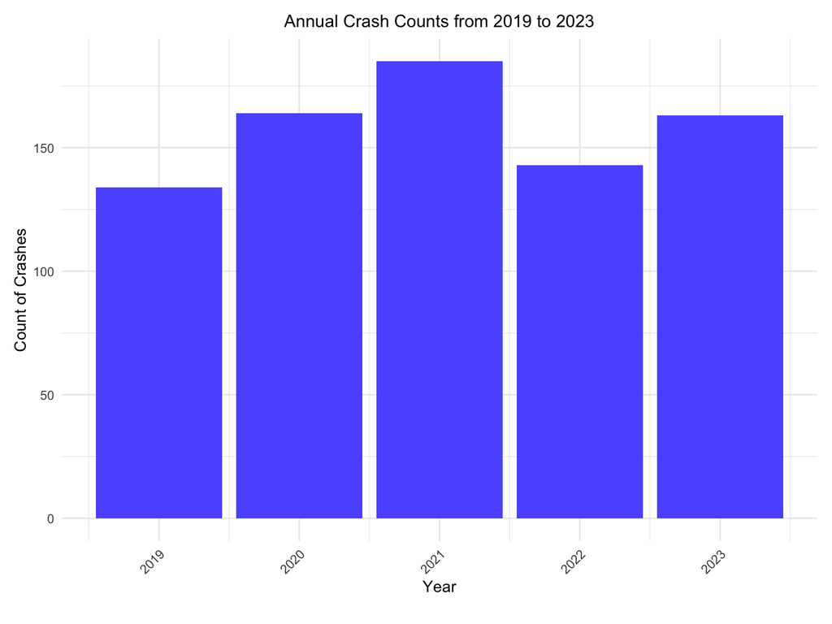

```r
# group by year
annual_counts <- crash %>%
  group_by(DATE_VAL_Y) %>%
  summarise(Count = n(), .groups = 'drop')

# plot annual crash counts
ggplot(annual_counts, aes(x = DATE_VAL_Y, y = Count)) +
  geom_col(fill = "#5e5eff") +
  labs(title = "Annual Crash Counts from 2019 to 2023",
       x = "Year",
       y = "Count of Crashes") +
  theme_minimal() +
  theme(
    plot.title = element_text(hjust = 0.5, size = 12),
    axis.text.x = element_text(angle = 45, hjust = 1),
    plot.margin = margin(t = 10, r = 10, b = 20, l = 10)
  )
```

- The chart shows annual crash counts in the City of Charlotte from 2019 to 2023. Crashes increased in 2020,peaked in 2021 then declined in 2022 before and rising again in 2023. I am unsure whether this is higher than the U.S. national average or not. need to use more data to compare.

##### Plot the crash points from 2019 to 2023 using kernel density estimation and overlay the proposed intersection points on the map for comparison.

```r
crash <- st_transform(crash, 32119)
safe_project <- st_transform(safe_project, 32119)
population_group <- st_transform(population_group, 32119)
gradient_color <- colorRampPalette(c("#ffffff", "#FEC44F", "#ff6600"))(5)

win <- as.owin(st_bbox(crash))

# kernal density
pts <- st_coordinates(crash)
ppp_obj <- ppp(pts[,1], pts[,2], window = win)
```

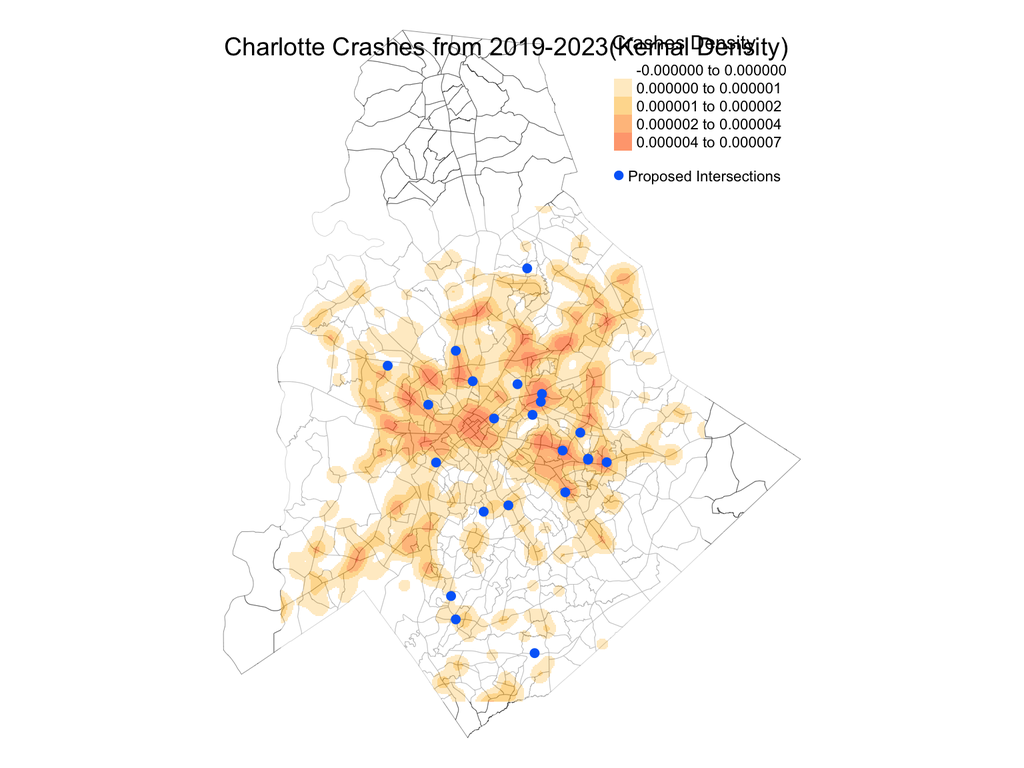

```r
kde <- density.ppp(ppp_obj,
                  sigma = 500, # adjust smooth parameter
                  eps = c(100, 100)) # grid size

# convert to raster data
r <- raster(as.im(kde))
crs(r) <- st_crs(crash)$wkt
# plot density map
tm_shape(population_group) +
tm_borders(col = "#5a5a5a", lwd = 0.3) +
tm_shape(r) +
  tm_raster(palette = gradient_color,
            title = "Crashes Density",
            alpha = 0.6,
            style = "fisher") +
  tm_layout(title = "Charlotte Crashes from 2019-2023(Kernal Density)",
            title.size = 1.2,
            frame = FALSE) +
  tm_shape(safe_project) +
  tm_dots(col = "#006cf9", size = 0.2) +
  tm_add_legend(type = "symbol",
                labels = "Proposed Intersections",
                col = "#006cf9",
                shape = 16,
                size = 0.5)
```

- This kernel density map of Charlotte crashes (2019–2023) shows that while most crashes are concentrated in central urban areas, some blue points (proposed intersections) are located in low-density regions. I think these points suggest that, despite lower crash frequencies, certain less populated or suburban areas still pose safety risks. If I have more time, I might can do more research to understand how the Charlotte city government made this decision.

#### Calculate crash density for each area, such as crashes per square kilometer or per capita to characterize each area

```r
crash <- st_read("Fatal_or_Serious_Injury_Crashes.geojson")
safe_project <- st_read("Safe_Streets_For_All_Grant_Projects.geojson")
commuting_group <- st_read("Census_Commuting_Block_Groups.geojson")
population_group <- st_read("Census_Population_Block_Groups.geojson")
# Step 1: Spatial join crash points into population_group
population_group_with_crash_count <- population_group %>%
  st_join(crash, join = st_intersects) %>%
  group_by(GEOID10) %>%
  summarise(crash_count = n(), .groups = 'drop')
head(population_group_with_crash_count)
```

```
## Simple feature collection with 6 features and 2 fields
## Geometry type: POLYGON
## Dimension:     XY
## Bounding box:  xmin: -80.85519 ymin: 35.20489 xmax: -80.83343 ymax: 35.23434
## Geodetic CRS:  WGS 84
## # A tibble: 6 × 3
##   GEOID10      crash_count                                              geometry
##   <chr>              <int>                                         <POLYGON [°]>
## 1 371190001001           1 ((-80.84446 35.22839, -80.84514 35.22897, -80.84566 …
## 2 371190001002           2 ((-80.84404 35.23319, -80.84475 35.2338, -80.84521 3…
## 3 371190001003           2 ((-80.84075 35.23202, -80.84183 35.23126, -80.84207 …
## 4 371190001004           1 ((-80.83572 35.22607, -80.83565 35.22611, -80.83504 …
## 5 371190001005           6 ((-80.85002 35.22212, -80.85012 35.22202, -80.85025 …
## 6 371190003001           2 ((-80.83603 35.21041, -80.83597 35.21059, -80.83589 …
```

```r
# Step 2: Left join population_group with commuting_group
commuting_group_df <- as.data.frame(st_drop_geometry(commuting_group))
second_df <- population_group_with_crash_count %>%
  left_join(commuting_group_df, by = "GEOID10") %>%
  select(GEOID10, Workers_16_and_older, Drove_alone, Carpool,
         Public_Transportation, Walked,
         crash_count)

str(second_df)
```

```
## sf [555 × 8] (S3: sf/tbl_df/tbl/data.frame)
##  $ GEOID10              : chr [1:555] "371190001001" "371190001002" "371190001003" "371190001004" ...
##  $ Workers_16_and_older : int [1:555] 1023 1415 645 71 438 461 1525 904 1095 816 ...
##  $ Drove_alone          : int [1:555] 583 818 460 46 353 500 1105 709 643 475 ...
##  $ Carpool              : int [1:555] 34 28 45 0 0 13 64 75 70 30 ...
##  $ Public_Transportation: int [1:555] 0 14 23 0 0 13 77 162 126 42 ...
##  $ Walked               : int [1:555] 627 512 384 20 99 31 319 160 342 335 ...
##  $ crash_count          : int [1:555] 1 2 2 1 6 2 1 1 7 1 ...
##  $ geometry             :sfc_POLYGON of length 555; first list element: List of 1
##   ..$ : num [1:103, 1:2] -80.8 -80.8 -80.8 -80.8 -80.8 ...
##   ..- attr(*, "class")= chr [1:3] "XY" "POLYGON" "sfg"
##  - attr(*, "sf_column")= chr "geometry"
##  - attr(*, "agr")= Factor w/ 3 levels "constant","aggregate",..: NA NA NA NA NA NA NA
##   ..- attr(*, "names")= chr [1:7] "GEOID10" "Workers_16_and_older" "Drove_alone" "Carpool" ...
```

```r
#Step 3: Left join second_df with population_group
population_group_df <- as.data.frame(st_drop_geometry(population_group))
final_df <- second_df %>%
  left_join(population_group_df, by = "GEOID10") %>%
  select(GEOID10, Workers_16_and_older, Drove_alone, Carpool,
         Public_Transportation, Walked, Population, Shape__Area,
         crash_count, geometry)

str(final_df)
```

```
## sf [555 × 10] (S3: sf/tbl_df/tbl/data.frame)
##  $ GEOID10              : chr [1:555] "371190001001" "371190001002" "371190001003" "371190001004" ...
##  $ Workers_16_and_older : int [1:555] 1023 1415 645 71 438 461 1525 904 1095 816 ...
##  $ Drove_alone          : int [1:555] 583 818 460 46 353 500 1105 709 643 475 ...
##  $ Carpool              : int [1:555] 34 28 45 0 0 13 64 75 70 30 ...
##  $ Public_Transportation: int [1:555] 0 14 23 0 0 13 77 162 126 42 ...
##  $ Walked               : int [1:555] 627 512 384 20 99 31 319 160 342 335 ...
##  $ Population           : int [1:555] 1714 2095 1270 83 735 1115 1868 1622 1787 1244 ...
##  $ Shape__Area          : num [1:555] 5336135 1931299 2085154 4499538 7036154 ...
##  $ crash_count          : int [1:555] 1 2 2 1 6 2 1 1 7 1 ...
##  $ geometry             :sfc_POLYGON of length 555; first list element: List of 1
##   ..$ : num [1:103, 1:2] -80.8 -80.8 -80.8 -80.8 -80.8 ...
##   ..- attr(*, "class")= chr [1:3] "XY" "POLYGON" "sfg"
##  - attr(*, "sf_column")= chr "geometry"
##  - attr(*, "agr")= Factor w/ 3 levels "constant","aggregate",..: NA NA NA NA NA NA NA NA NA
##   ..- attr(*, "names")= chr [1:9] "GEOID10" "Workers_16_and_older" "Drove_alone" "Carpool" ...
```

#### Calcualte the index for clustering

```r
#step 1: calculate the index for clustering
#cloume crash density = crash_count/(Population/ Shape__Area
#walk_public_ratio = (Walked + Public_Transportation)/ Workers_16_and_older

cluster_df <- final_df %>%
  mutate(
    crash_density = ifelse(Population > 0 & Shape__Area > 0,
                           crash_count / (Population / Shape__Area),
                           NA),
    walk_public_ratio = ifelse(Workers_16_and_older > 0,
                               (Walked + Public_Transportation) / Workers_16_and_older,
                               NA)
  )

# standardize the index for clustering
cluster_df <- cluster_df %>%
  mutate(
    crash_density_norm = (crash_density - min(crash_density, na.rm = TRUE)) /
                         (max(crash_density, na.rm = TRUE) - min(crash_density, na.rm = TRUE)),
    walk_public_ratio_norm = (walk_public_ratio - min(walk_public_ratio, na.rm = TRUE)) /
                             (max(walk_public_ratio, na.rm = TRUE) - min(walk_public_ratio, na.rm = TRUE))
  )

# check NA values
sapply(cluster_df, function(x) sum(is.na(x)))
```

```
##                GEOID10   Workers_16_and_older            Drove_alone
##                      0                      0                      0
##                Carpool  Public_Transportation                 Walked
##                      0                      0                      0
##             Population            Shape__Area            crash_count
##                      0                      0                      0
##               geometry          crash_density      walk_public_ratio
##                      0                      2                      2
##     crash_density_norm walk_public_ratio_norm
##                      2                      2
```

```r
clustering_data <- cluster_df %>%
  filter(!is.na(crash_density_norm) & !is.na(walk_public_ratio_norm)) %>%
  st_drop_geometry() %>%
  select(crash_density_norm, walk_public_ratio_norm)


set.seed(50)
kmeans_result <- kmeans(clustering_data, centers = 4)

cluster_df$cluster <- NA
non_na_indices <- which(!is.na(cluster_df$crash_density_norm) & !is.na(cluster_df$walk_public_ratio_norm))
cluster_df$cluster[non_na_indices] <- kmeans_result$cluster

# check cluster_df$cluster
table(cluster_df$cluster, useNA = "ifany")
```

```
##
##    1    2    3    4 <NA>
##  147   17  337   52    2
```

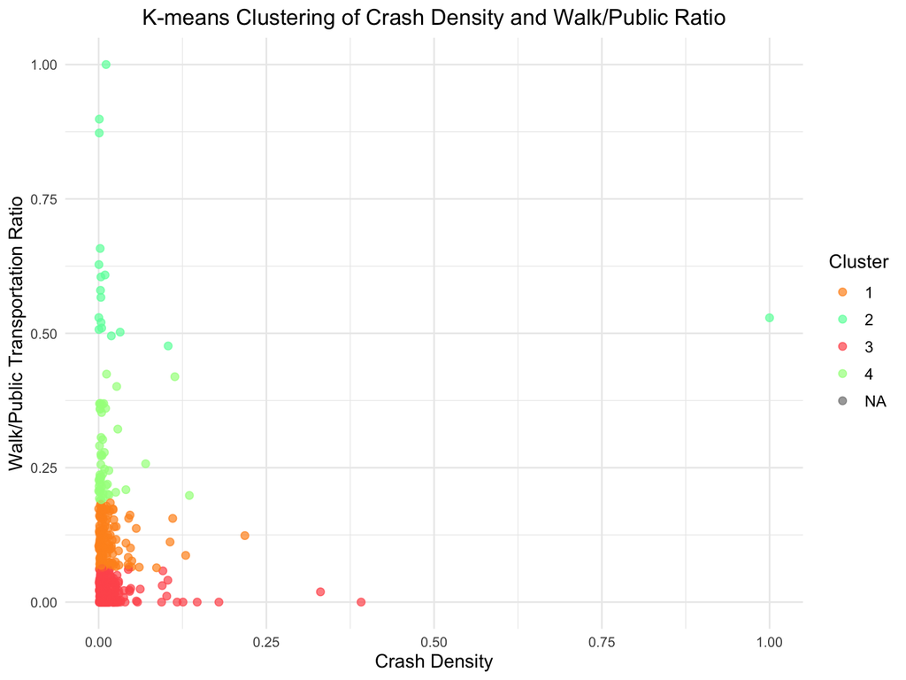

```r
ggplot(cluster_df, aes(x = crash_density_norm, y = walk_public_ratio_norm, color = as.factor(cluster))) +
  geom_point(size = 2, alpha = 0.7) +
  labs(title = "K-means Clustering of Crash Density and Walk/Public Ratio",
       x = "Crash Density",
       y = "Walk/Public Transportation Ratio",
       color = "Cluster") +
  theme_minimal() +
  theme(
    plot.title = element_text(hjust = 0.5, size = 14),
    axis.title = element_text(size = 12),
    legend.title = element_text(size = 12),
    legend.text = element_text(size = 10)
  ) +
  scale_color_manual(values = c("#ff9320", "#69fda9", "#ff5a5a", "#a2ff8b"))
```

- The current clustering results are not very good due to a lack of time to process outlier data. However, it can be observed that most areas are concentrated in scenarios with low public transportation and walked rate and there tend to have higher crash density.

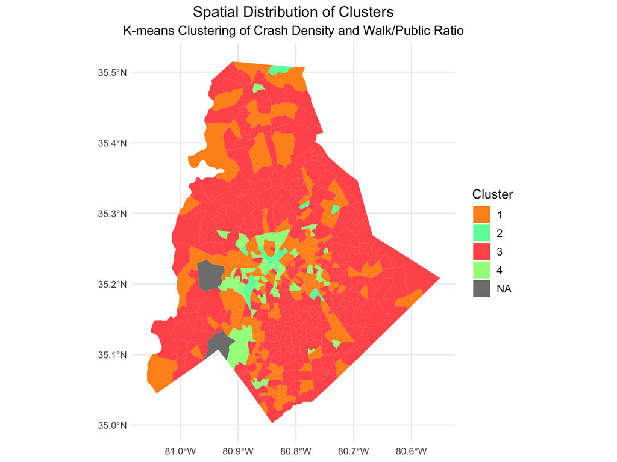

```r
custom_colors <- c("#ff9320", "#69fda9", "#ff5a5a", "#a2ff8b")

ggplot(data = cluster_df) +
  geom_sf(aes(fill = as.factor(cluster)), color = NA) +
  scale_fill_manual(values = custom_colors, name = "Cluster") +
  labs(title = "Spatial Distribution of Clusters",
       subtitle = "K-means Clustering of Crash Density and Walk/Public Ratio") +
  theme_minimal() +
  theme(
    plot.title = element_text(hjust = 0.5, size = 14),
    plot.subtitle = element_text(hjust = 0.5, size = 12),
    legend.title = element_text(size = 12),
    legend.text = element_text(size = 10)
  )
```

### Conclusion

- Although the frequency of accidents is higher in the city center, certain suburban or less populated areas still pose safety risks. The clustering results indicate that areas with low public transportation and walking rates tend to have higher accident densities, which may require further research and policy intervention. Due to time constraints, the clustering results may not be ideal, and future efforts could focus on handling outlier data to improve the accuracy of the analysis.